# HW2

Burak Şimşek - IE582 - Fall 2020

12/5/2020

```r
#loading libraries
library(ggplot2)
library(dplyr)
library(tidyverse)
library(data.table)
library(scatterplot3d)
```

```r
#reading dataframes
x_train=read.table("https://raw.githubusercontent.com/BU-IE-582/fall20-buraksimsekkk/master/HW2/uWaveGestureLibrary_X_TRAIN.txt")
y_train=read.table("https://raw.githubusercontent.com/BU-IE-582/fall20-buraksimsekkk/master/HW2/uWaveGestureLibrary_Y_TRAIN.txt")
z_train=read.table("https://raw.githubusercontent.com/BU-IE-582/fall20-buraksimsekkk/master/HW2/uWaveGestureLibrary_Z_TRAIN.txt")
```

# PART A

### Read Data and Plot Gestures

Finding first indexes for each class.

```r
class_ind = c()

for(i in 1:8)
  {
  class_ind[i]  <-which(x_train$V1==i)[1]

  }
```

To obtain gesture graph, firstly, data tables are made created for specified indexes from previous chunk. The velocity and location matrix are calculated respectively by taking cumsum. At last 3d visualization of gesture are made with scatterplot3d.

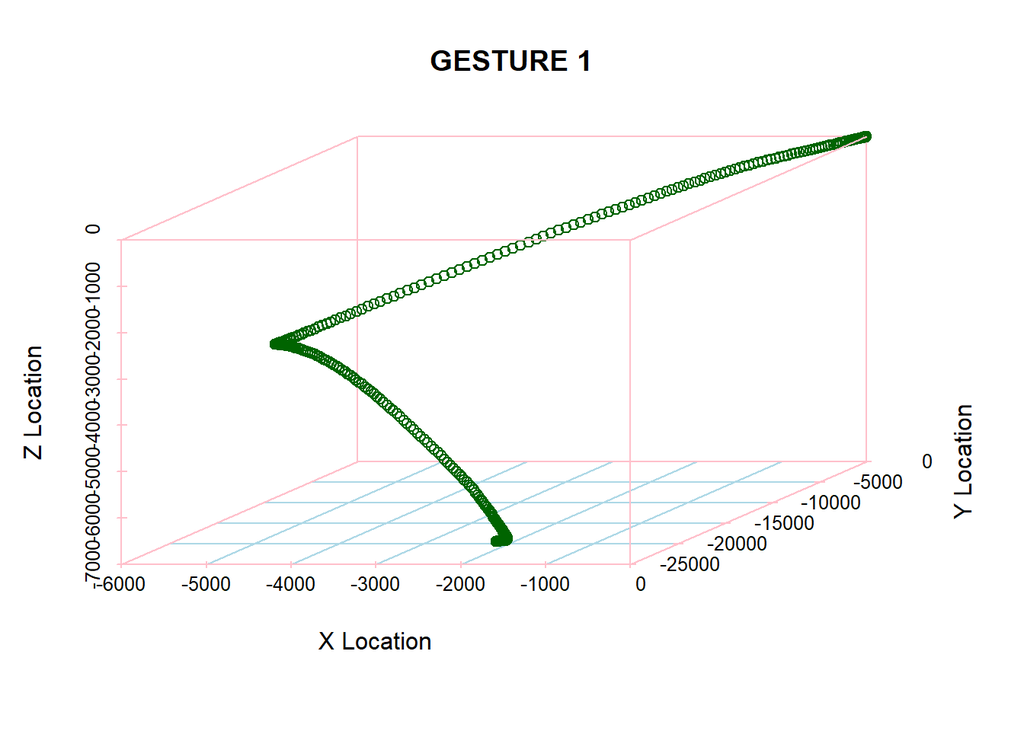

```r
  i=1
  gesture1 <- data.table(x=t(x_train[class_ind[i],2:316]),
                         y=t(y_train[class_ind[i],2:316]),
                         z=t(z_train[class_ind[i],2:316]))

  vel_gesture1 <- cumsum(gesture1)
  loc_gesture1 <- cumsum(vel_gesture1)

    scatterplot3d(loc_gesture1$x.11,loc_gesture1$y.11,loc_gesture1$z.11,  main = "GESTURE 1",xlab = "X Location",ylab = "Y Location",zlab = "Z Location",col.axis="pink", col.grid="lightblue", color = "darkgreen", type = "p")
```

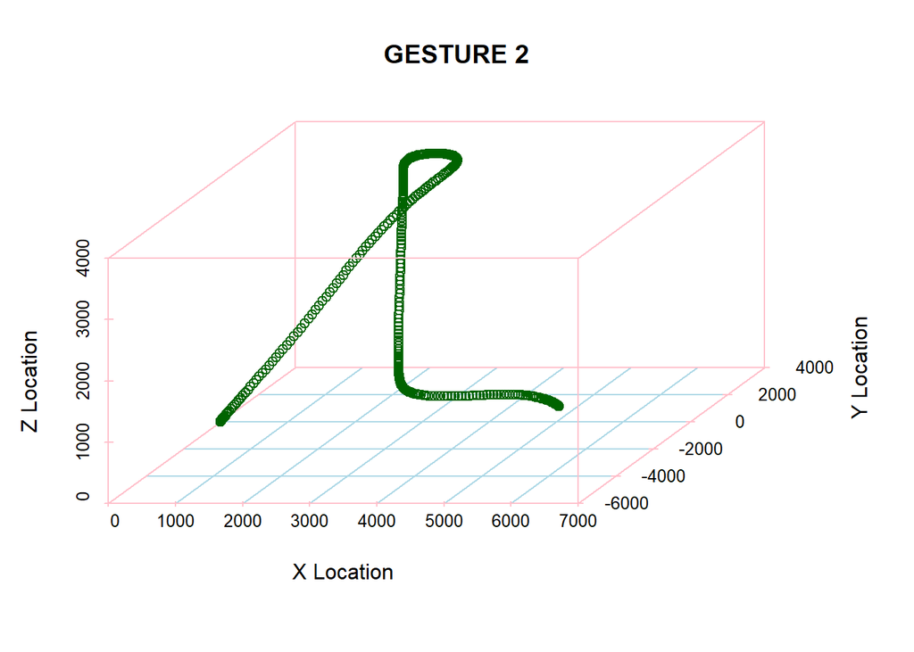

```r
  i=2
  gesture2 <- data.table(x=t(x_train[class_ind[i],2:316]),
                         y=t(y_train[class_ind[i],2:316]),
                         z=t(z_train[class_ind[i],2:316]))

  vel_gesture2 <- cumsum(gesture2)
  loc_gesture2 <- cumsum(vel_gesture2)

    scatterplot3d(loc_gesture2$x.15,loc_gesture2$y.15,loc_gesture2$z.15,  main = "GESTURE 2",xlab = "X Location",ylab = "Y Location",zlab = "Z Location",col.axis="pink", col.grid="lightblue", color = "darkgreen", type = "p")
```

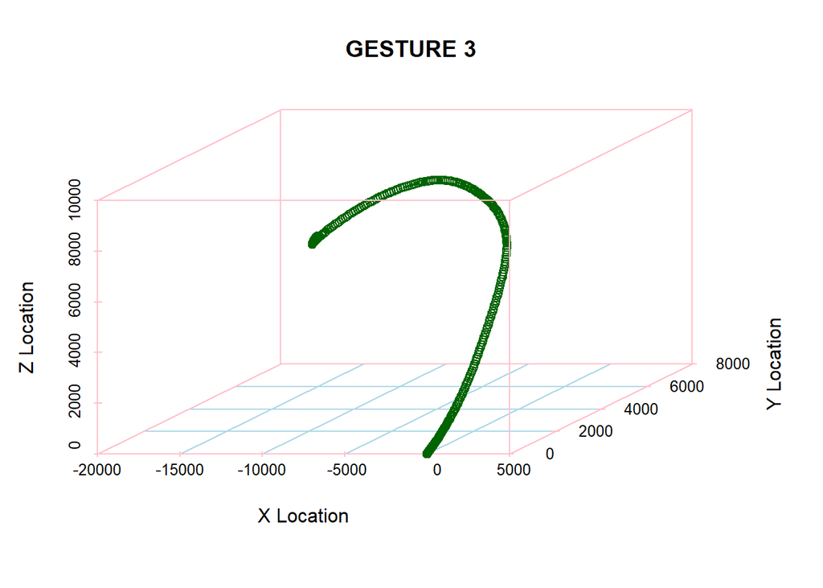

```r
  i=3
  gesture3 <- data.table(x=t(x_train[class_ind[i],2:316]),
                         y=t(y_train[class_ind[i],2:316]),
                         z=t(z_train[class_ind[i],2:316]))
  vel_gesture3 <- cumsum(gesture3)
  loc_gesture3 <- cumsum(vel_gesture3)


    scatterplot3d(loc_gesture3$x.4,loc_gesture3$y.4,loc_gesture3$z.4,  main = "GESTURE 3",xlab = "X Location",ylab = "Y Location",zlab = "Z Location",col.axis="pink", col.grid="lightblue", color = "darkgreen", type = "p")
```

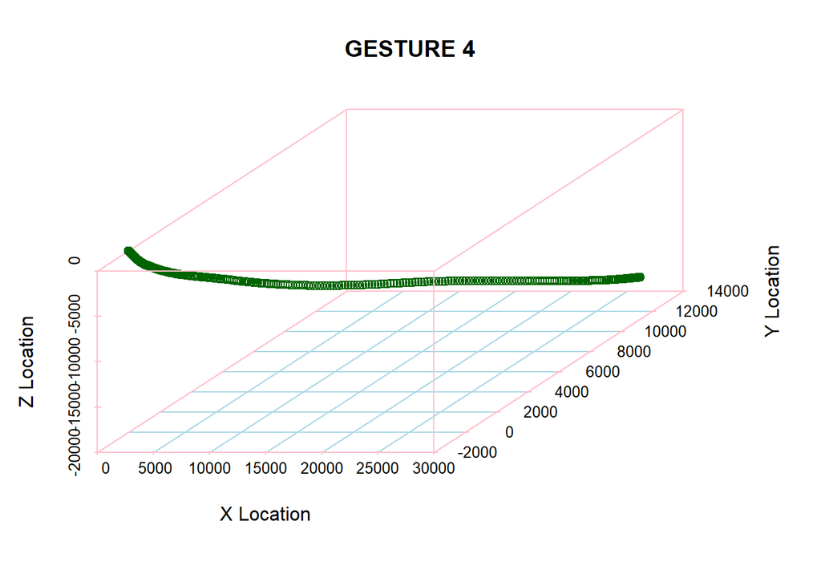

```r
  i=4
  gesture4 <- data.table(x=t(x_train[class_ind[i],2:316]),
                         y=t(y_train[class_ind[i],2:316]),
                         z=t(z_train[class_ind[i],2:316]))

  vel_gesture4 <- cumsum(gesture4)
  loc_gesture4 <- cumsum(vel_gesture4)

    scatterplot3d(loc_gesture4$x.5,loc_gesture4$y.5,loc_gesture4$z.5,  main = "GESTURE 4",xlab = "X Location",ylab = "Y Location",zlab = "Z Location",col.axis="pink", col.grid="lightblue", color = "darkgreen", type = "p")
```

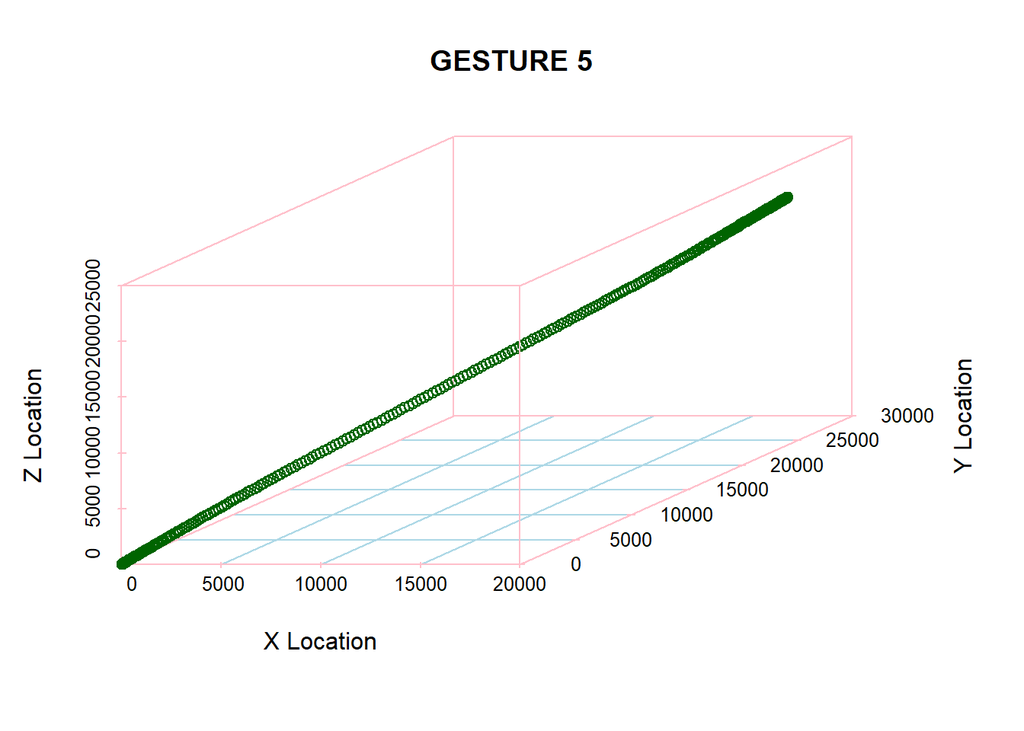

```r
  i=5
  gesture5 <- data.table(x=t(x_train[class_ind[i],2:316]),
                         y=t(y_train[class_ind[i],2:316]),
                         z=t(z_train[class_ind[i],2:316]))

  vel_gesture5 <- cumsum(gesture5)
  loc_gesture5 <- cumsum(vel_gesture5)

    scatterplot3d(loc_gesture5$x.2,loc_gesture5$y.2,loc_gesture5$z.2,  main = "GESTURE 5",xlab = "X Location",ylab = "Y Location",zlab = "Z Location",col.axis="pink", col.grid="lightblue", color = "darkgreen", type = "p")
```

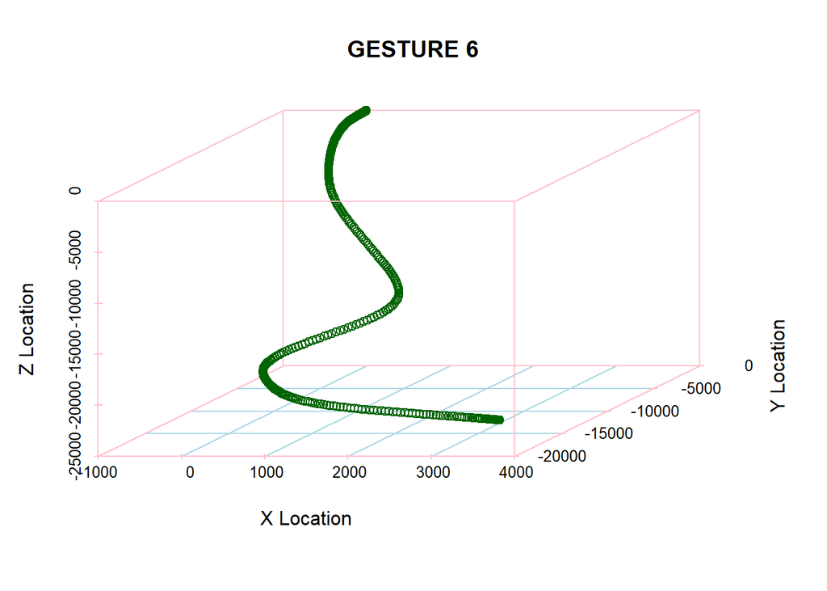

```r
  i=6
  gesture6 <- data.table(x=t(x_train[class_ind[i],2:316]),
                         y=t(y_train[class_ind[i],2:316]),
                         z=t(z_train[class_ind[i],2:316]))

  vel_gesture6 <- cumsum(gesture6)
  loc_gesture6 <- cumsum(vel_gesture6)

    scatterplot3d(loc_gesture6$x.1,loc_gesture6$y.1,loc_gesture6$z.1,  main = "GESTURE 6",xlab = "X Location",ylab = "Y Location",zlab = "Z Location",col.axis="pink", col.grid="lightblue", color = "darkgreen", type = "p")
```

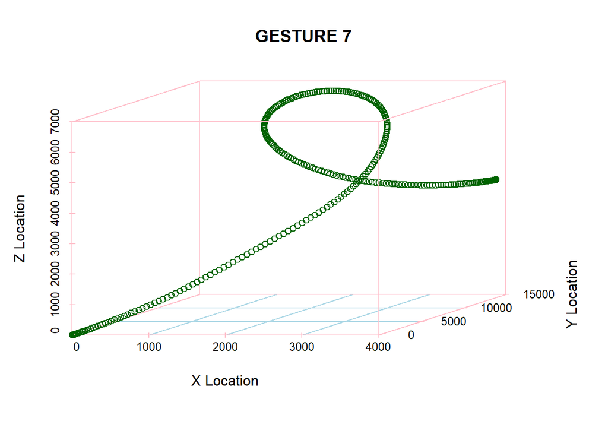

```r
  i=7
  gesture7 <- data.table(x=t(x_train[class_ind[i],2:316]),
                         y=t(y_train[class_ind[i],2:316]),
                         z=t(z_train[class_ind[i],2:316]))

  vel_gesture7 <- cumsum(gesture7)
  loc_gesture7 <- cumsum(vel_gesture7)

    scatterplot3d(loc_gesture7$x.7,loc_gesture7$y.7,loc_gesture7$z.7,  main = "GESTURE 7",xlab = "X Location",ylab = "Y Location",zlab = "Z Location",col.axis="pink", col.grid="lightblue", color = "darkgreen", type = "p")
```

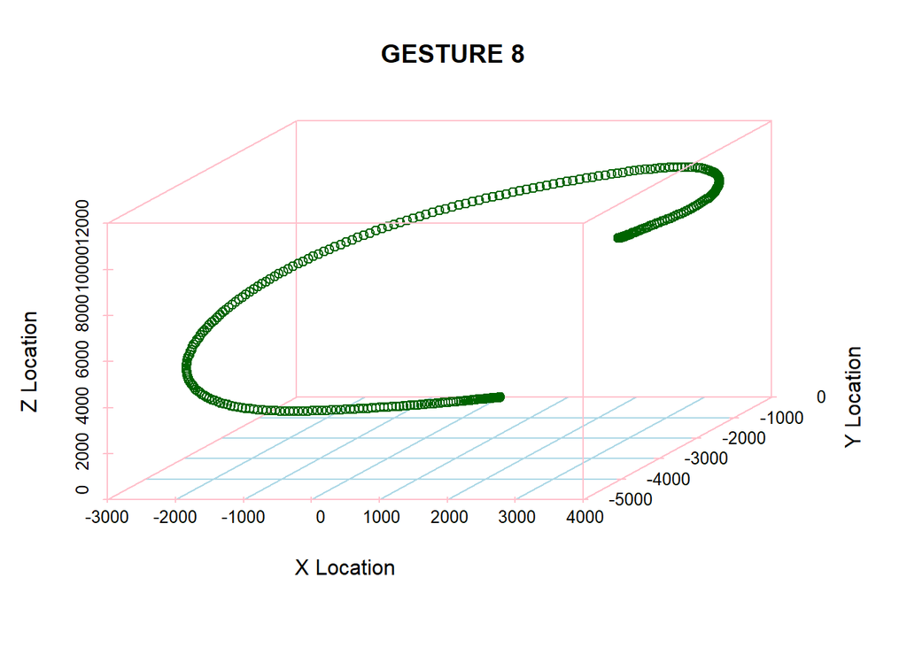

```r
  i=8
  gesture8 <- data.table(x=t(x_train[class_ind[i],2:316]),
                         y=t(y_train[class_ind[i],2:316]),
                         z=t(z_train[class_ind[i],2:316]))
  vel_gesture8 <- cumsum(gesture8)
  loc_gesture8 <- cumsum(vel_gesture8)


    scatterplot3d(loc_gesture8$x.6,loc_gesture8$y.6,loc_gesture8$z.6,  main = "GESTURE 8",xlab = "X Location",ylab = "Y Location",zlab = "Z Location",col.axis="pink", col.grid="lightblue", color = "darkgreen", type = "p")
```

# PART B ### PCA Analysis and Ploting 2 Random Class Data

In this part raw data manipulated for long format. For each axis (x,y,z), location matrixes are found like part a. Then obtaion long format by using melt function.

```r
class <- x_train[1]
colnames(class)[1] = "class"


x_acc <- x_train[-1]
x_velocity <- t(apply(x_acc, 1, cumsum))
x_location <- t(apply(x_velocity, 1, cumsum))
x_location <- cbind(x_location,class)
x_position <- as.data.table(x_location) %>% mutate(time_series_id = seq(nrow(x_location)))
x_long     <- x_position %>% melt(id.vars = c("class", "time_series_id"))
colnames(x_long)[3] = "time_index"
colnames(x_long)[4] = "X"

y_acc <- y_train[-1]
y_velocity <- t(apply(y_acc, 1, cumsum))
y_location <- t(apply(y_velocity, 1, cumsum))
y_location    <- cbind(y_location,class)
y_position <- as.data.table(y_location) %>% mutate(time_series_id = seq(nrow(y_location)))
y_long     <- melt(y_position, id.vars = c("class", "time_series_id"))
colnames(y_long)[3] = "time_index"
colnames(y_long)[4] = "Y"

z_acc <- z_train[-1]
z_velocity <- t(apply(z_acc, 1, cumsum))
z_location <- t(apply(z_velocity, 1, cumsum))
z_location <- cbind(z_location,class)
z_position <- as.data.table(z_location) %>% mutate(time_series_id = seq(nrow(z_location)))
z_long     <- melt(z_position, id.vars = c("class", "time_series_id"))
colnames(z_long)[3] = "time_index"
colnames(z_long)[4] = "Z"
```

Arranging long format by adding y and z values to x_long data table and arrange table by time series id.

```r
xyz_long <- cbind(x_long, y_long[,4], z_long[,4] )
xyz_long <- arrange(xyz_long, time_series_id)
```

Dimension reduction applied with pca from 3D to 1D. Summary describe that univariate function can cover up around %54 of 3D data. It can be covered up til %90 in 2 dimension.

```r
pca <- princomp(xyz_long[,4:6], cor=T)
summary(pca)
```

```
## Importance of components:
##                           Comp.1    Comp.2    Comp.3
## Standard deviation     1.2724995 1.0380930 0.5505524
## Proportion of Variance 0.5397517 0.3592124 0.1010360
## Cumulative Proportion  0.5397517 0.8989640 1.0000000
```

By using univariate function, prediction point for each time index are made. Then, randomly selected 16 time series (2 time series for each class) are plotted.

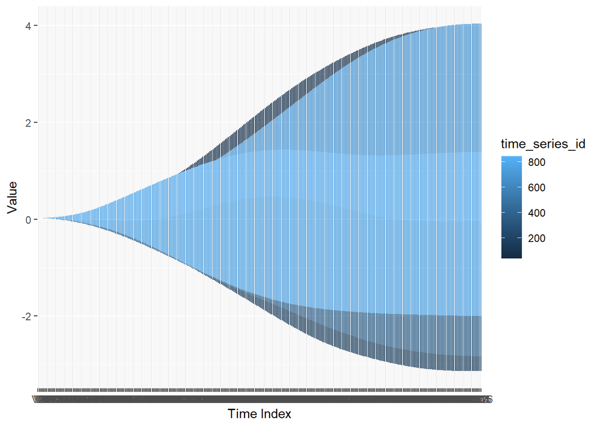

```r
univariate <- xyz_long %>% mutate(value = predict(pca,xyz_long[,4:6])[,1]) %>%  select(-X, -Y, -Z)


example <- univariate %>% filter(time_series_id %in% c(38,82,94,95,96,184,199,371,378,481,515,642,713,779,820,845))



ggplot(example, aes(x= time_index, y= value , colour=time_series_id)) +
       geom_line() + xlab("Time Index") + ylab("Value") + theme(plot.title=element_text(hjust = 0.5))
```

Observing 2 random time series for class 1. Both time series has similer pattern. Therefore, univariate form might be sufficient to dissociate classes from each other.

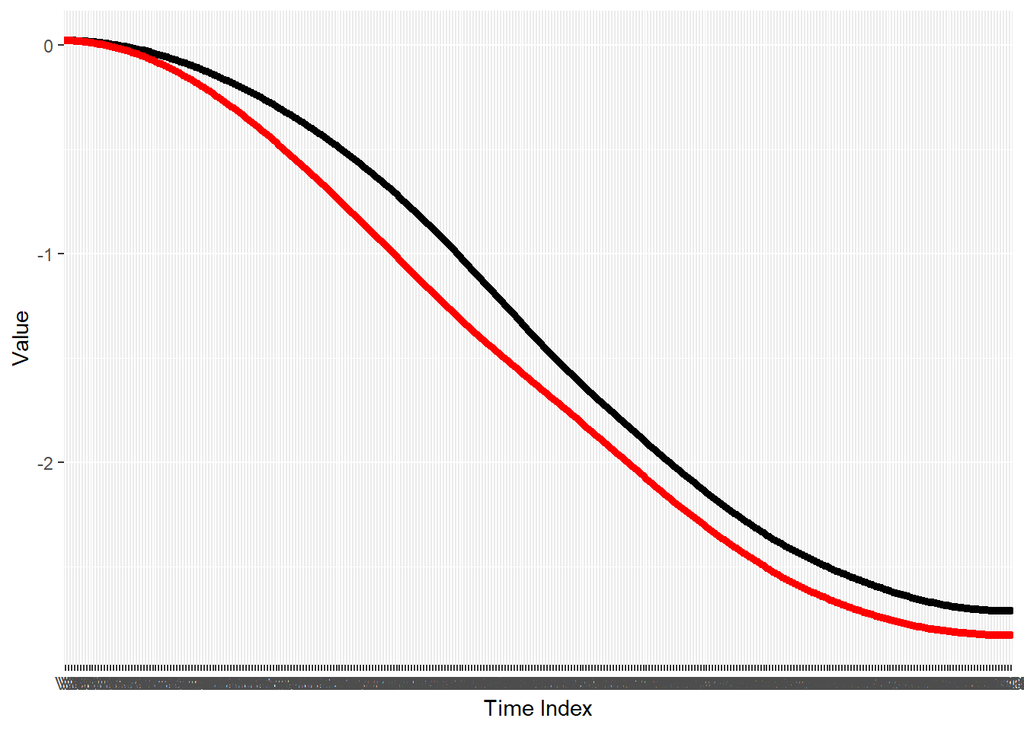

```r
line_1  <- univariate %>% filter(time_series_id ==38  )
line_2  <- univariate %>% filter(time_series_id ==378 )

class_1 <- cbind(line_1 , line_2$value)

colnames(class_1)[4] = "line_1"
colnames(class_1)[5] = "line_2"

print(ggplot(class_1) + geom_point(aes(x=time_index, y=line_1)) + geom_point(aes(x=time_index, y=line_2), color = "red") + xlab("Time Index") + ylab("Value"))
```

Observing 2 random time series for class 2. Time series has different pattern Therefore, univariate form might not be sufficient to dissociate classes from each other.It can be better to use 2 dimensional form to cover up more datas.

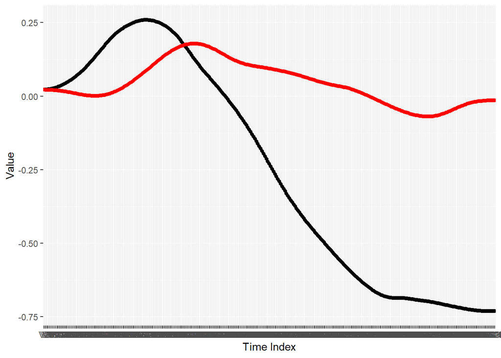

```r
line_3  <- univariate %>% filter(time_series_id ==82  )
line_4  <- univariate %>% filter(time_series_id ==481 )

class_2 <- cbind(line_3 , line_4$value)

colnames(class_2)[4] = "line_3"
colnames(class_2)[5] = "line_4"

print(ggplot(class_2) + geom_point(aes(x=time_index, y=line_3)) + geom_point(aes(x=time_index, y=line_4), color = "red") + xlab("Time Index") + ylab("Value"))
```

Observing 2 random time series for class 3. Time series has different pattern Therefore, univariate form might not be sufficient to dissociate classes from each other.It can be better to use 2 dimensional form to cover up more datas.

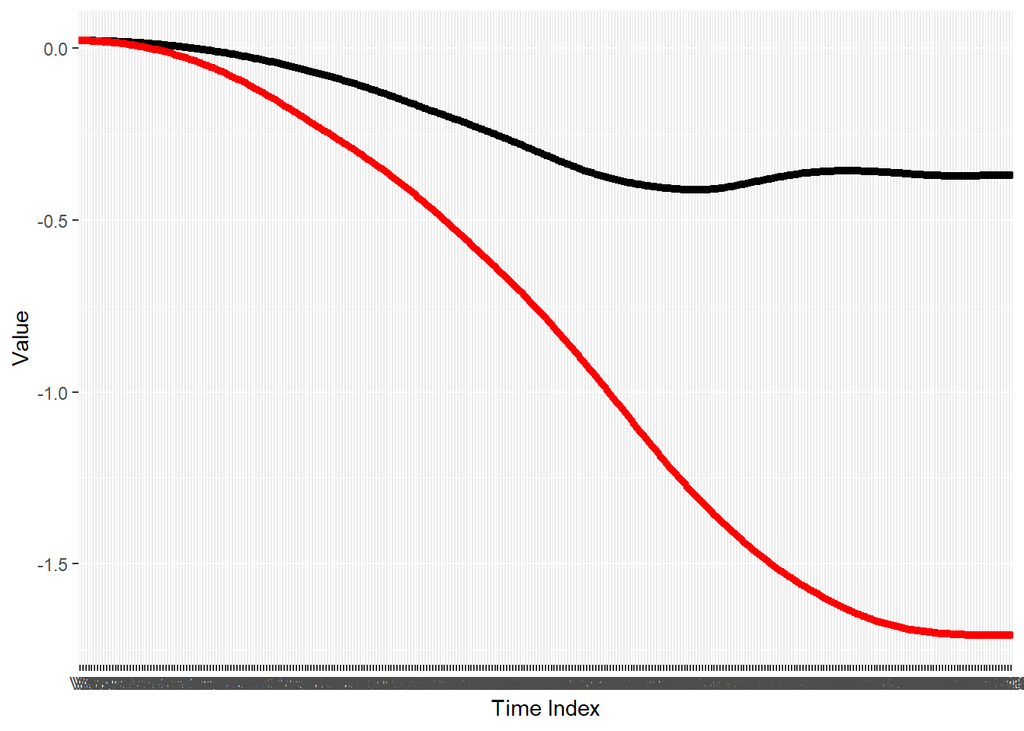

```r
line_5  <- univariate %>% filter(time_series_id ==94  )
line_6  <- univariate %>% filter(time_series_id ==515 )

class_3 <- cbind(line_5 , line_6$value)
colnames(class_3)[4] = "line_5"
colnames(class_3)[5] = "line_6"

print(ggplot(class_3) + geom_point(aes(x=time_index, y=line_5)) + geom_point(aes(x=time_index, y=line_6), color = "red") + xlab("Time Index") + ylab("Value"))
```

Observing 2 random time series for class 4. Time series has different pattern Therefore, univariate form might not be sufficient to dissociate classes from each other.It can be better to use 2 dimensional form to cover up more datas.

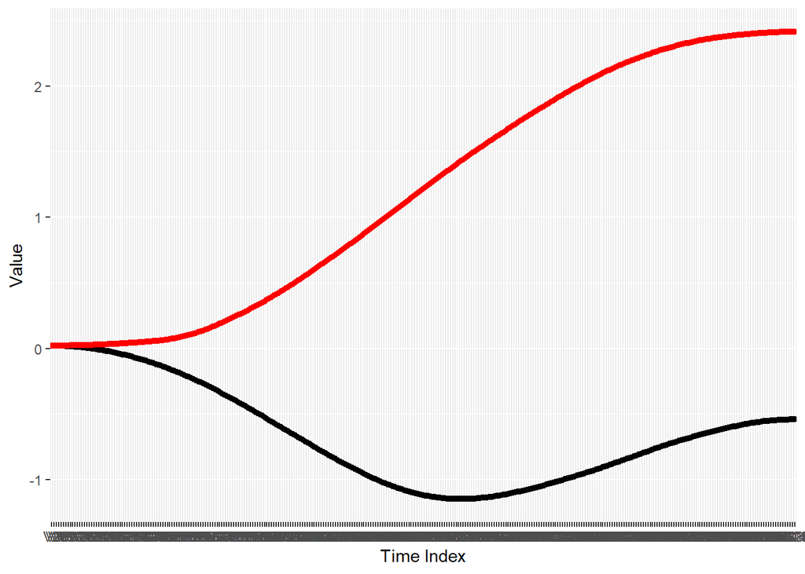

```r
line_7  <- univariate %>% filter(time_series_id ==95  )
line_8  <- univariate %>% filter(time_series_id ==642 )

class_4 <- cbind(line_7 , line_8$value)

colnames(class_4)[4] = "line_7"
colnames(class_4)[5] = "line_8"

print(ggplot(class_4) + geom_point(aes(x=time_index, y=line_7)) + geom_point(aes(x=time_index, y=line_8), color = "red") + xlab("Time Index") + ylab("Value"))
```

Observing 2 random time series for class 5. Both time series has similer pattern. Therefore, univariate form might be sufficient to dissociate classes from each other.

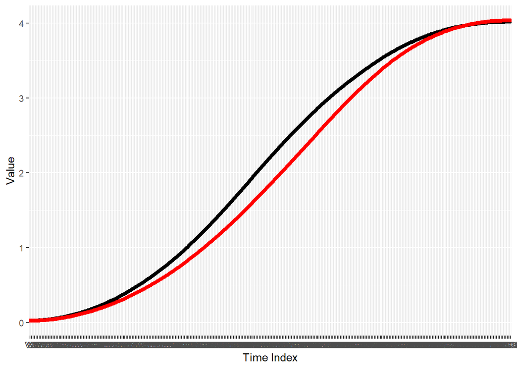

```r
line_9  <- univariate %>% filter(time_series_id ==96  )
line_10 <- univariate %>% filter(time_series_id ==713 )

class_5 <- cbind(line_9 , line_10$value)

colnames(class_5)[4] = "line_9"
colnames(class_5)[5] = "line_10"

print(ggplot(class_5) + geom_point(aes(x=time_index, y=line_9)) + geom_point(aes(x=time_index, y=line_10), color = "red") + xlab("Time Index") + ylab("Value"))
```

Observing 2 random time series for class 6. Both time series has similer pattern. Therefore, univariate form might be sufficient to dissociate classes from each other.

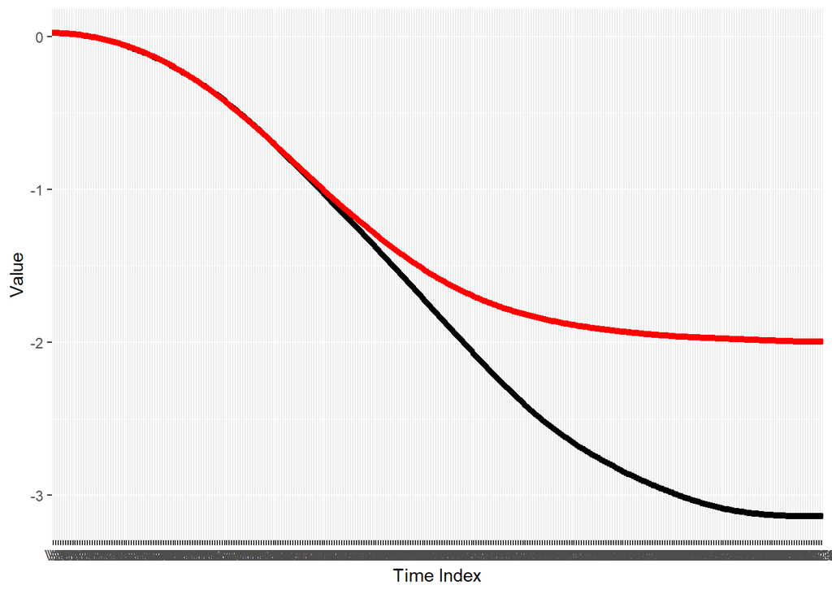

```r
line_11 <- univariate %>% filter(time_series_id ==184 )
line_12 <- univariate %>% filter(time_series_id ==779 )

class_6 <- cbind(line_11 , line_12$value)

colnames(class_6)[4] = "line_11"
colnames(class_6)[5] = "line_12"

print(ggplot(class_6) + geom_point(aes(x=time_index, y=line_11)) + geom_point(aes(x=time_index, y=line_12), color = "red") + xlab("Time Index") + ylab("Value"))
```

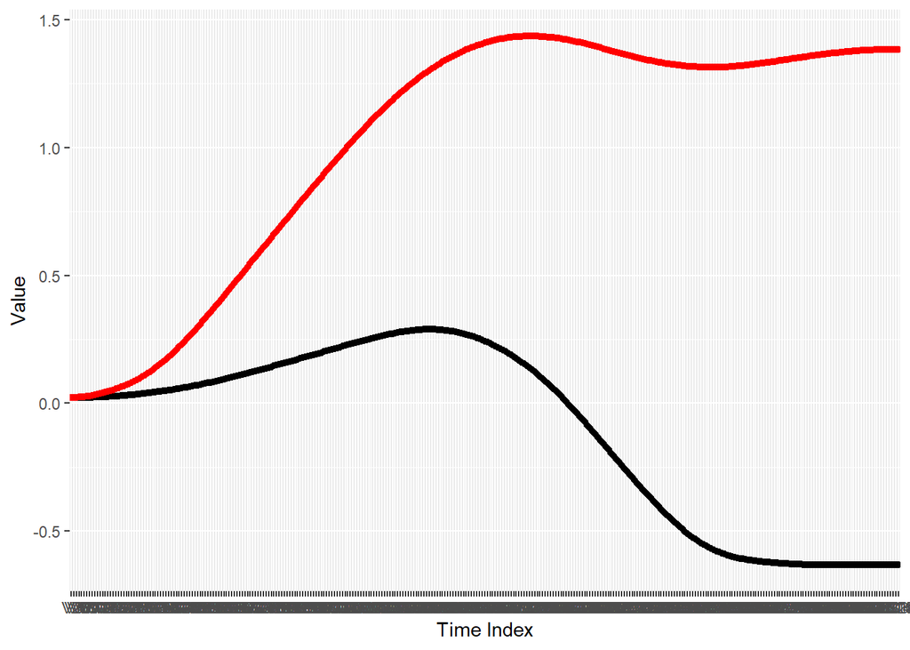

```r
line_13 <- univariate %>% filter(time_series_id ==199 )
line_14 <- univariate %>% filter(time_series_id ==820 )

class_7 <- cbind(line_13 , line_14$value)

colnames(class_7)[4] = "line_13"
colnames(class_7)[5] = "line_14"

print(ggplot(class_7) + geom_point(aes(x=time_index, y=line_13)) + geom_point(aes(x=time_index, y=line_14), color = "red") + xlab("Time Index") + ylab("Value"))
```

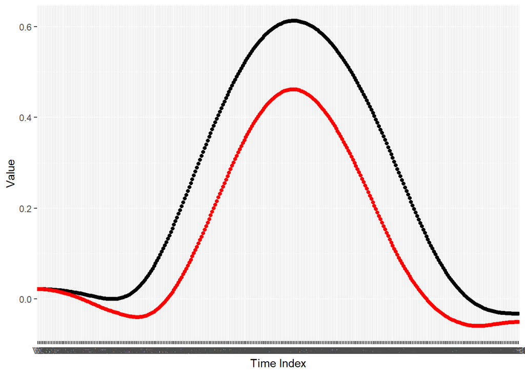

```r
line_15 <- univariate %>% filter(time_series_id ==371 )
line_16 <- univariate %>% filter(time_series_id ==845 )

class_8 <- cbind(line_15 , line_16$value)

colnames(class_8)[4] = "line_15"
colnames(class_8)[5] = "line_16"

print(ggplot(class_8) + geom_point(aes(x=time_index, y=line_15)) + geom_point(aes(x=time_index, y=line_16), color = "red") + xlab("Time Index") + ylab("Value"))
```

# PART C

### Appying PCA for Each Class Individually and Observe Similarities

Previously, PCA was applied for all data. In this part, PCA are applied for each class seperately. Variances covered by component 1 are between %42 and %65. It was %54 in previous part. It can be said that choosing all data or choosing class datas seperatesly does not change the result. Moreover, variances covered by component 1 and 2 is almost similar too.

```r
for (i in 1:8){
xyz_long_class <- xyz_long %>% filter(class==i)
pca_class <- prcomp(xyz_long_class[,4:6], scale=TRUE)
print("Summary for Class:"[i])
  print(i)
print(summary(pca_class))
cat("\n")
cat("\n")}
```

```
## [1] "Summary for Class:"
## [1] 1
## Importance of components:
##                           PC1    PC2   PC3
## Standard deviation     1.2932 1.0091 0.556
## Proportion of Variance 0.5575 0.3395 0.103
## Cumulative Proportion  0.5575 0.8970 1.000
##
##
## [1] NA
## [1] 2
## Importance of components:
##                           PC1    PC2    PC3
## Standard deviation     1.1287 0.9457 0.9120
## Proportion of Variance 0.4246 0.2981 0.2773
## Cumulative Proportion  0.4246 0.7227 1.0000
##
##
## [1] NA
## [1] 3
## Importance of components:
##                           PC1    PC2    PC3
## Standard deviation     1.2156 1.0028 0.7188
## Proportion of Variance 0.4926 0.3352 0.1722
## Cumulative Proportion  0.4926 0.8278 1.0000
##
##
## [1] NA
## [1] 4
## Importance of components:
##                           PC1    PC2    PC3
## Standard deviation     1.2856 0.9915 0.6035
## Proportion of Variance 0.5509 0.3277 0.1214
## Cumulative Proportion  0.5509 0.8786 1.0000
##
##
## [1] NA
## [1] 5
## Importance of components:
##                           PC1    PC2     PC3
```

[output cut: 15 more lines]

```
## [1] 7
## Importance of components:
##                           PC1    PC2    PC3
## Standard deviation     1.2972 0.8884 0.7267
## Proportion of Variance 0.5609 0.2631 0.1760
## Cumulative Proportion  0.5609 0.8240 1.0000
##
##
## [1] NA
## [1] 8
## Importance of components:
##                           PC1    PC2    PC3
## Standard deviation     1.2203 0.9683 0.7571
## Proportion of Variance 0.4964 0.3125 0.1911
## Cumulative Proportion  0.4964 0.8089 1.0000
```

# PART D

### Visualize classification by Using Reduce Dimentions in Time Series

In this particular example, it is tried to classified 8 different gesture. One of the best method for classification is distance method. In this part, euclidean distance are applied to find distance between points and mapped on 2d plan.

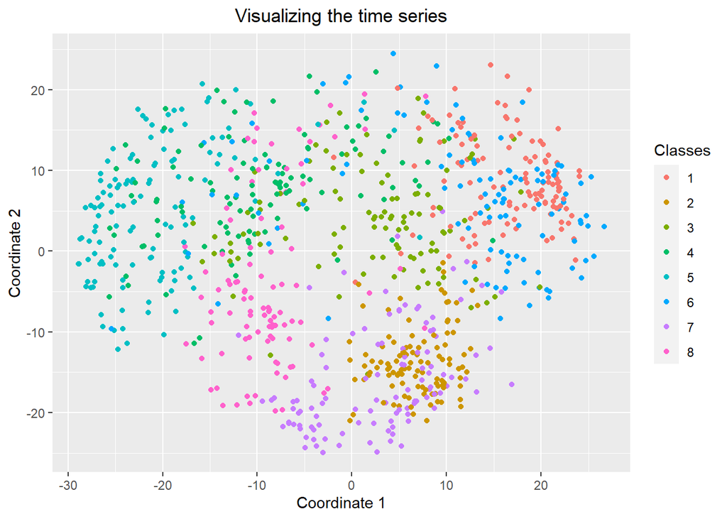

```r
all_data<- cbind(x_train,y_train[,-1],z_train[,-1])
all_data[,-1]=scale(all_data[,-1])

distance = as.matrix(dist(all_data[,-1], method = "euclidean"))


scale <- cmdscale(distance, k=2)
scale_data <- all_data %>% select(V1) %>% mutate(coord1=scale[,1], coord2=scale[,2], Classes = as_factor(V1))

ggplot(scale_data) + geom_point(aes(x=coord1, y=coord2, colour=Classes)) + xlab("Coordinate 1") + ylab("Coordinate 2") + theme(plot.title=element_text(hjust = 0.5)) + ggtitle("Visualizing the time series")
```